# Data Visualization

Yue Gu

```r
library(dplyr)
```

```r
library(ggplot2)
library(readr)
```

```r
nc <- read_csv("https://docs.google.com/spreadsheets/d/e/2PACX-1vTm2WZwNBoQdZhMgot7urbtu8eG7tzAq-60ZJsQ_nupykCAcW0OXebVpHksPWyR4x8xJTVQ8KAulAFS/pub?gid=202410847&single=true&output=csv")
glimpse(nc)
```

```
## Rows: 800
## Columns: 13
## $ fage           <dbl> 19, 21, 18, 17, 20, 30, 21, 14, 16, 20, 18, 20, 20, 26,…
## $ mage           <dbl> 15, 15, 15, 15, 16, 16, 16, 16, 16, 17, 17, 17, 17, 17,…
## $ mature         <chr> "younger mom", "younger mom", "younger mom", "younger m…
## $ weeks          <dbl> 37, 41, 37, 35, 37, 45, 38, 40, 24, 40, 37, 40, 39, 38,…
## $ premie         <chr> "full term", "full term", "full term", "premie", "full …
## $ visits         <dbl> 11, 6, 12, 5, 13, 9, 15, 12, 5, 8, 10, 17, 9, 11, 10, 1…
## $ marital        <chr> "married", "married", "married", "married", "married", …
## $ gained         <dbl> 38, 34, 76, 15, 52, 28, 75, 9, 12, 20, 39, 38, 36, 30, …
## $ weight         <dbl> 6.63, 8.00, 8.44, 4.69, 6.94, 7.44, 7.56, 5.81, 1.50, 8…
## $ lowbirthweight <chr> "not low", "not low", "not low", "low", "not low", "not…
## $ gender         <chr> "female", "male", "male", "male", "female", "male", "fe…
## $ habit          <chr> "nonsmoker", "nonsmoker", "nonsmoker", "nonsmoker", "no…
## $ whitemom       <chr> "white", "white", "not white", "not white", "white", "w…
```

## Exercise 1

Note: Even though the tag besides “visits” said “doubles”, doubles act as a label for all numeric including integers and fractions according to the ModernDive textbook. Therefore, we should view the actual values in the data frame to figure out what specific type of values a variable is.

1. R considers the variable “habit” as characters.
2. The variable “visits” is considered as numbers, more specifically, integers.

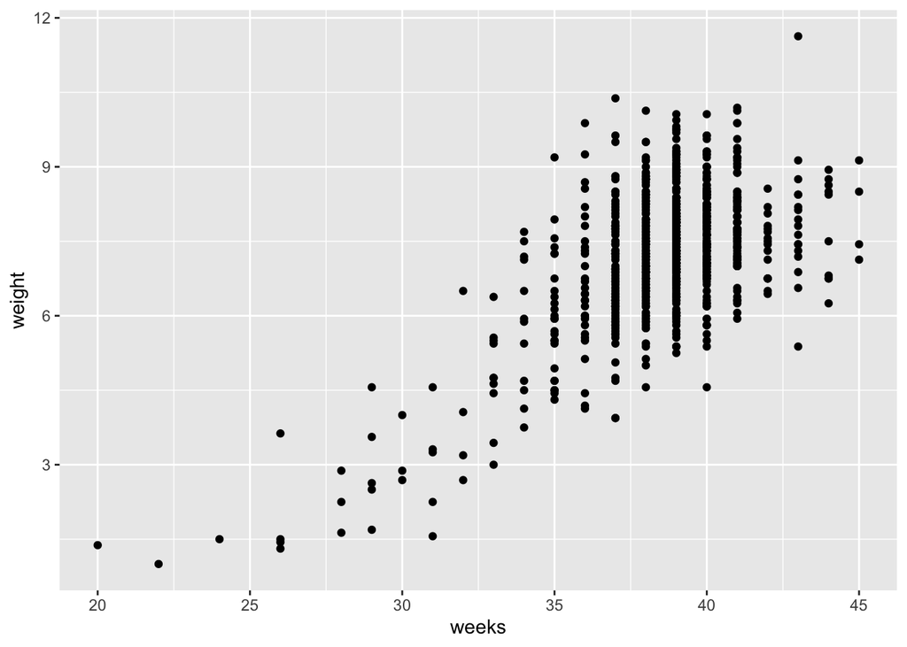

```r
ggplot(data = nc, aes(x = weeks, y = weight)) +
  geom_point()
```

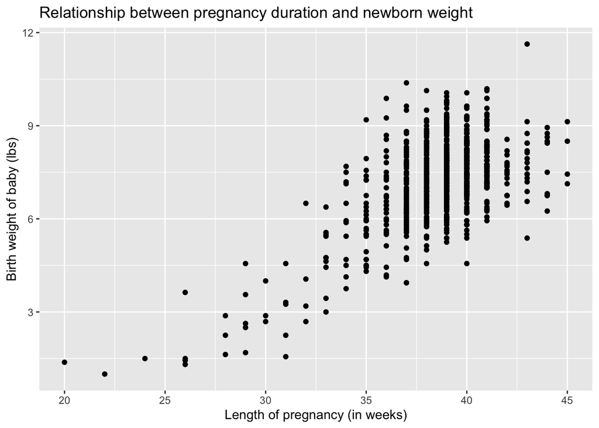

```r
ggplot(data = nc, aes(x = weeks, y = weight)) +
  geom_point() +
  labs(x = "Length of pregnancy (in weeks)", y = "Birth weight of baby (lbs)",
       title = "Relationship between pregnancy duration and newborn weight")
```

## Exercise 2

1. There is a positive relationship between the variable “length of pregnancy” and variable “birth weight for baby”. As the length of pregnancy increases, the birth weight for baby increases.

## Exercise 3

Note: Don’t forget to put on the units as standards of measurement in axis labels!

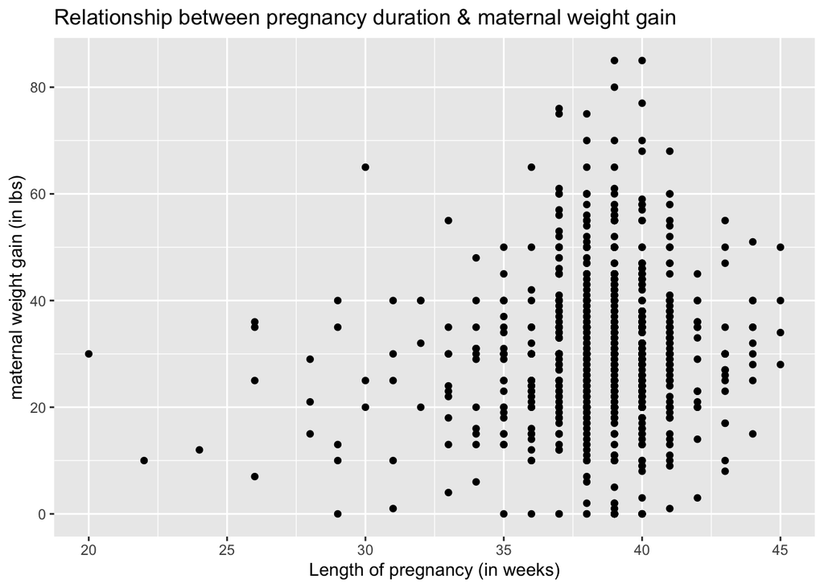

```r
ggplot(data = nc, aes(x = weeks, y = gained)) +
  geom_point() +
  labs(x = "Length of pregnancy (in weeks)", y = "maternal weight gain (in lbs)",
       title = "Relationship between pregnancy duration & maternal weight gain")
```

## Exercise 4

C. 37 weeks appears to be the pregnancy length cutoff for classifying a newborn as a “premie” versus a “full-term” delivery.

## Exercise 5

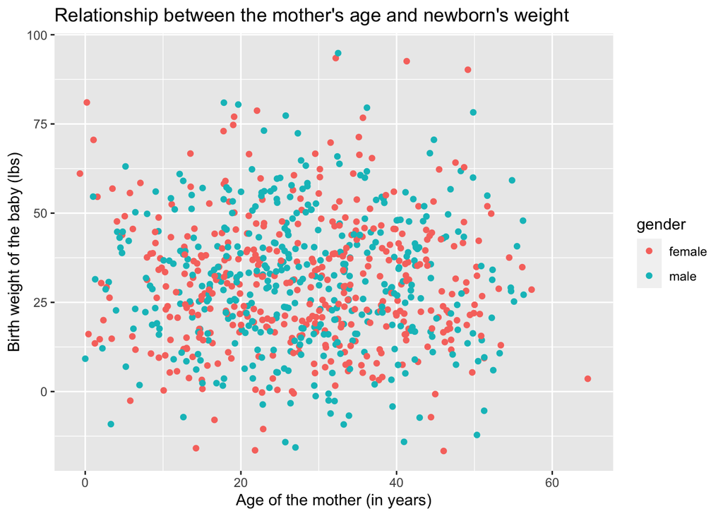

```r
ggplot(data = nc, aes(x = mage, y = gained, color = gender)) +
  geom_jitter(width = 20, height = 20) +
  labs(x = "Age of the mother (in years)", y = "Birth weight of the baby (lbs)",
       title = "Relationship between the mother's age and newborn's weight")
```

## Histograms

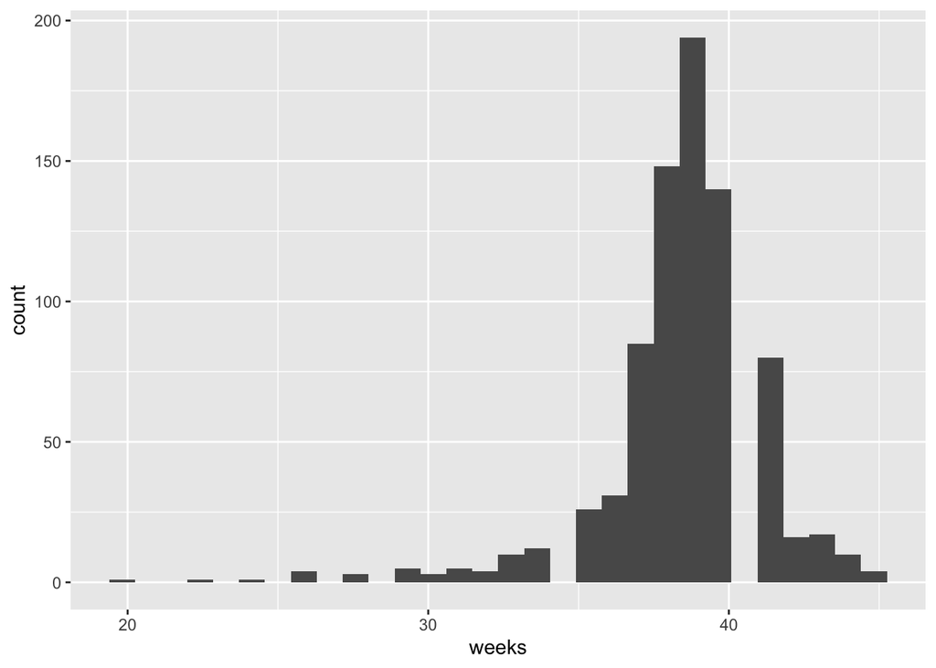

```r
ggplot(data = nc, aes(x = weeks))+
  geom_histogram()
```

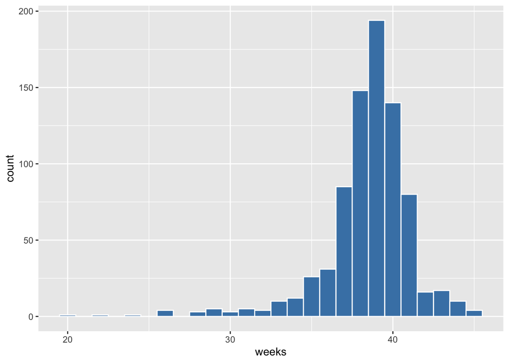

```r
ggplot(data = nc, aes(x = weeks))+
  geom_histogram(binwidth = 1, color = "white", fill = "steelblue")
```

## Exercise 6

A. The number of newborns is counted.

B. The average length of pregnancies is about 38 weeks.

C. There will be only 1 bin. About 800 cases would be in the bin.

## Exercise 7

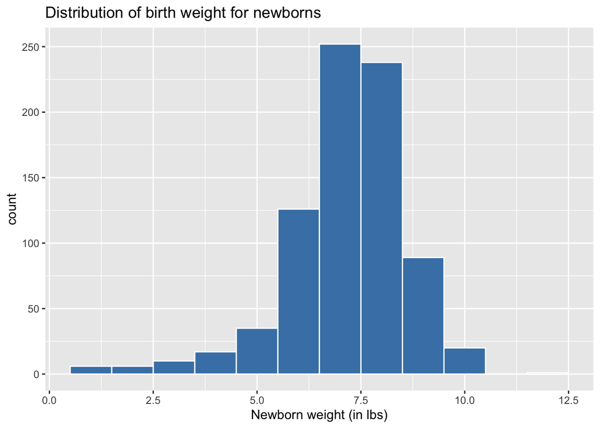

```r
ggplot(data = nc, aes(x = weight)) +
  geom_histogram(binwidth = 1, color = "white", fill = "steelblue") +
  labs(x = "Newborn weight (in lbs)",
       title = "Distribution of birth weight for newborns")
```

## Exercise 8

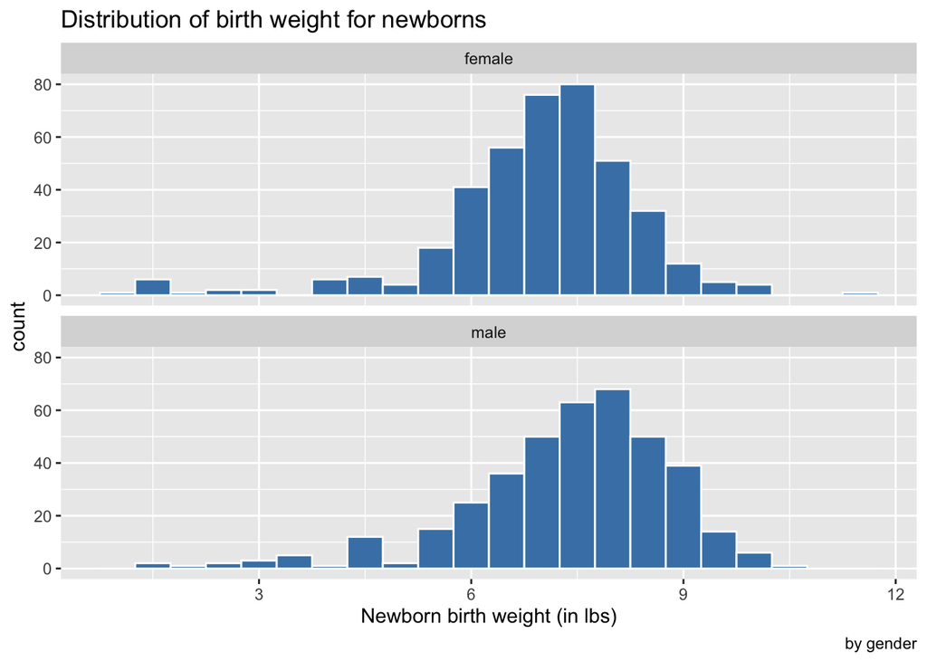

```r
ggplot(data = nc, aes(x = weight)) +
  geom_histogram(binwidth = 0.5, color = "white", fill = "steelblue") +
  labs(x = "Newborn birth weight (in lbs)",
       title = "Distribution of birth weight for newborns",
       caption = "by gender") +
  facet_wrap(~ gender, ncol = 1)
```

1. Males appear to have a slightly larger average birth weight.

## Exercise 9

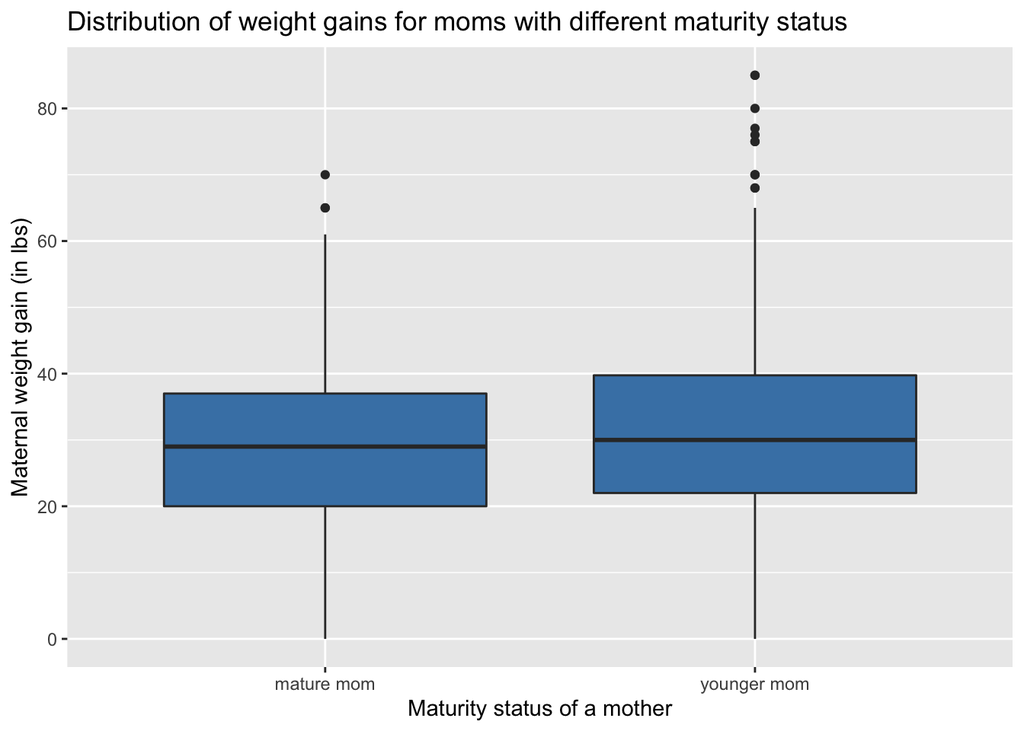

```r
ggplot(data = nc, aes(x = mature, y = gained)) +
  geom_boxplot(fill = "steelblue") +
  labs(x = "Maturity status of a mother", y = "Maternal weight gain (in lbs)",
       title = "Distribution of weight gains for moms with different maturity status")
```

1. The median weight gain during pregnancy is a bit larger for younger moms than for older moms.

## Exercise 10

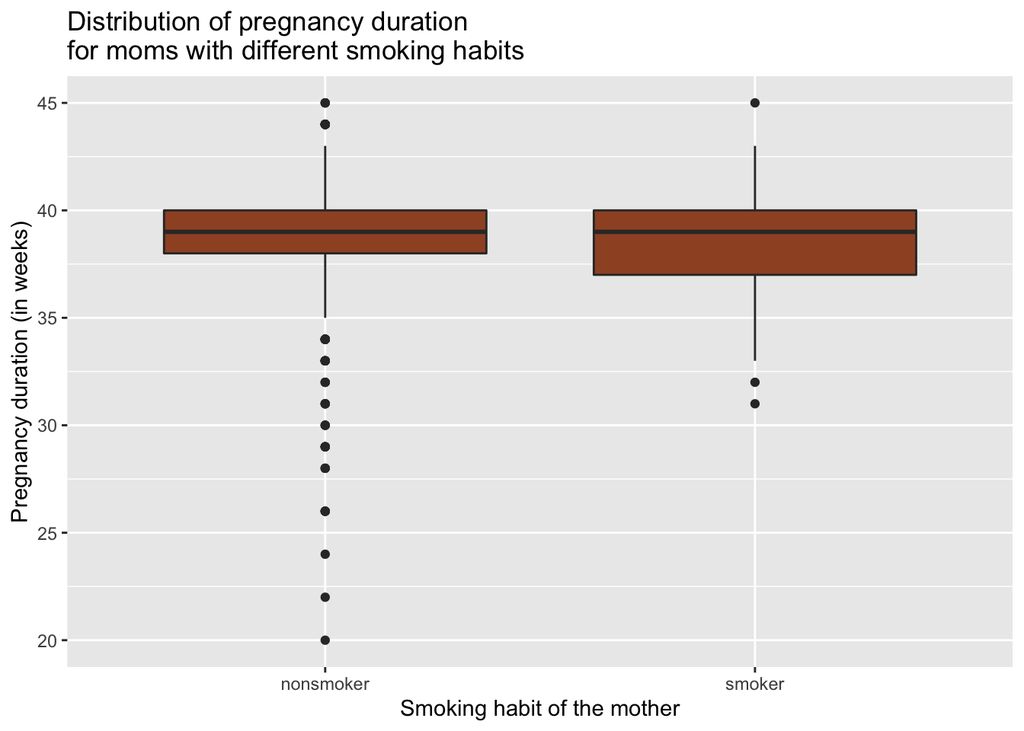

```r
ggplot(data = nc, aes(x = habit, y = weeks)) +
  geom_boxplot(fill = "sienna") +
  labs(x = "Smoking habit of the mother", y = "Pregnancy duration (in weeks)",
       title = "Distribution of pregnancy duration\nfor moms with different smoking habits")
```

1. The duration of pregnancy is more variable for smokers than for non-smokers.

## Exercise 11

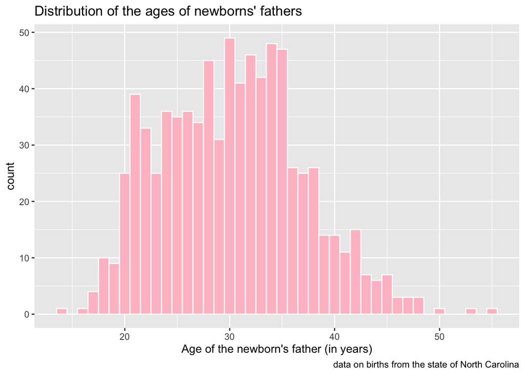

```r
ggplot(data = nc, mapping = aes(x = fage)) +
  geom_histogram(binwidth = 1, color = "white", fill = "pink") +
  labs(x = "Age of the newborn's father (in years)",
       title = "Distribution of the ages of newborns' fathers",
       caption = "data on births from the state of North Carolina")
```

## Exercise 12

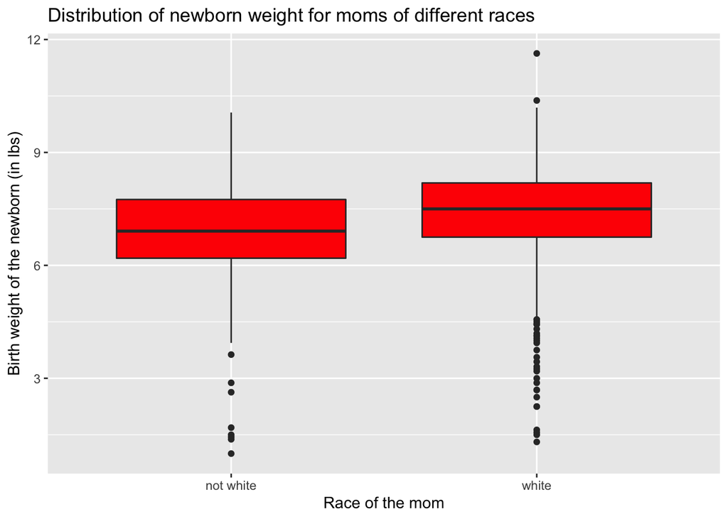

```r
ggplot(data = nc, mapping = aes(x = whitemom, y = weight)) +
  geom_boxplot(fill = "red") +
  labs(x = "Race of the mom", y = "Birth weight of the newborn (in lbs)",
       title = "Distribution of newborn weight for moms of different races")
```

1. By comparing the solid lines in the center of the boxes, it is indicated that the median birth weight of babies for white mothers is greater than the one for non-white mothers (the solid line in the center of the “white” box is located higher than the one in the “non-white” box).

## Exercise 13

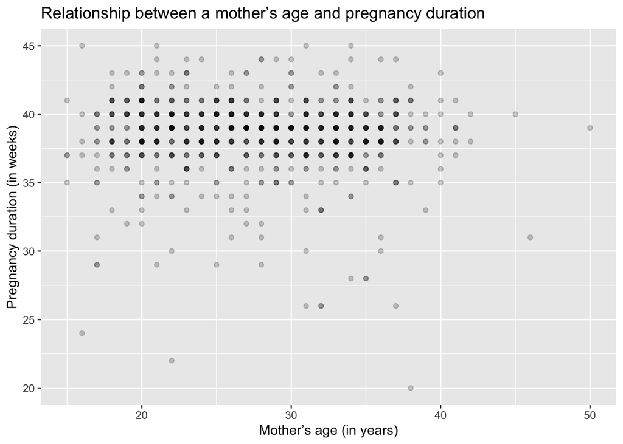

```r
ggplot(data = nc, mapping = aes(x = mage, y = weeks)) +
  geom_point(alpha = 0.2) +
  labs(x = "Mother’s age (in years)", y = "Pregnancy duration (in weeks)",
       title = "Relationship between a mother’s age and pregnancy duration")
```

1）I changed the points’ opacity to address overplotting, and it appears that in this sample, as a mother’s age increases, her duration of pregnancy does not decrease.